# **secr** simulations TEL

Murray Efford and John Boulanger

2026-10-09

# Telemetry-calibrated cue counts

These simulations test a MLE implementation of the 1-step method of Whittington et al. (2025a).

## Problem description

It has been generally recognised that spatial mark–resight studies require either data on the initial deployment of marks, allowing the spatial distribution of marked animals to be modelled, or strong assumptions about the distribution (e.g. spatially uniform) (Royle et al. 2014, Efford and Hunter 2018).

However, the papers of Margenau et al. (2022) and Whittington et al. (2025a) pointed to a way of analysing camera data for collared animals that is not prone to bias from unmodelled deployment of collars. They recognised that detection parameters (e.g. $\lambda_0$, $\sigma$) may be estimated from the collared animals alone. Combining the detection parameter estimates with observed counts in either a 2-stage- (Margenau et al. 2022) or 1-stage-process (Whittington et al. 2025a) yields estimates of population density.

We consider the following scenario

- data include telemetry locations for a sample of animals,
- deployment (attachment) of telemetry devices (e.g., radiocollars) is not modelled,
- the spatial distribution of AC of telemetered animals is unknown,
- detection histories (binary proximity or count) relate only to pre-marked telemetered individuals,
- there is a history for each telemetered individual (all-zero if not detected), and
- equivalent data (counts of detections) are collected for all individuals, whether marked and unmarked.

## Implementation in **secr** 5.5.1

As a check on the **secr** results, the same simulated data are also fitted by an independent maximum likelihood implementation in RTMB (Kristensen et al. 2016, Kristensen 2026) (see file ‘rtmb_marking.R’, listed in the Appendix). The RTMB implementation differs from the **secr** likelihood in modelling the total of sightings of unmarked animals as negative binomial rather than as Poisson with a variance scale factor.

## Settings

These are intended to follow the 24 scenarios considered by Whittington et al. (2025a Appendix Table S2). A grid of 81 cameras spanning 90 units on a side (Whittington et al. 2025a p.4 stated 120 units) lies within a 150 x 150 square region (possibly 149 x 149 in Whittington et al. 2025b).

The same conditions are used for simulation and fitting.

| Parameter | Value(s) |
| --- | --- |
| detectfn | ‘HHN’ |
| N | 60, 120 |
| D | c(60,120) / ca2.25 ha |
| lambda0 | low or high (each varies with sigma) |
| sigma | 4 or 8 units |
| noccasions | 5 |
| buffer | 30 units |
| mask spacing | 2.5 or 5 units (0.625 sigma) |

Four combinations of lambda0 and sigma are used (see scen).

## Package version, date and platform

```r
source('../setup.R')
nrepl   <- 1000
```

```
## R version 4.5.1 (2025-06-13 ucrt)
## Platform   x86_64-w64-mingw32/x64
## Running    Windows 11 x64 (build 26200)
## secr       5.5.1 2026-10-04
## secrdesign 2.10.2 2026-10-04
## Threads    20
## nrepl      1000
## Run        Tue Oct  6 21:45:47 2026
```

## Simulation code

The simulation function `fnc.create.SMR.data` from file ‘1a._gSMR_simStudy_functions_and_nimble_code.R’ of Whittington et al. (2025b) is used to generate each replicate capthist. It is copied here, along with the required function `e2dist`.

```r
# See Whittington et al. (2025b)

# 0. Function e2dist ####
e2dist <- function (x, y) {  # Function from scrbook package to calculate the distance between locations in 2 matrices.
  i <- sort(rep(1:nrow(y), nrow(x)))
  dvec <- sqrt((x[, 1] - y[i, 1])^2 + (x[, 2] - y[i, 2])^2)
  matrix(dvec, nrow = nrow(x), ncol = nrow(y), byrow = F)
}

# 0.  Function to simulate data ####

fnc.create.SMR.data <- function (N = N, nMarked = nMarked, sigma = 1, lam0 = 0.5, K = 5,
                                 n.camera.row = 9,
                                 xlims = c(1, 150), ylims = c(1, 150), xlim.R = c(30, 120), ylim.R = c(30, 120),
                                 nlocs = 100, plotSim = TRUE)
  # N = True number of animals in the state-space
  # nMarked = number of animals to capture and mark
  # sigma = scale parameter for home range size
  # lam0 = encounter rate at home range centre for resighting
  # K = number of resighting (eg camera) occasions
  # n.camera.row = sqrt(total number of cameras)
  # xlims = min and max coordinates of easting for the state-space
  # ylims = min and max coordinates of northing for the state-space
  # xlim.R = min and max coorindates of easting for the study area
  # ylim.R = min and max coordinates of northing for the study area.
  # nMarked = Is the number of marked animals.
  # nlocs = number of telemetry locations for each marked animal.
  # plotSim = whether to plot state space, detectors, capture summary, and resighting summary
{
  ## Camera coordinates
  coor0 <- seq(xlim.R[1], xlim.R[2], length = n.camera.row)
  X.camera <- cbind(rep(coor0, each=length(coor0)),rep(coor0, times=length(coor0)))

  J.camera <- nrow(X.camera)
  # Capture Process: activity centres and marked animals
  enoughMarked = FALSE
  counter <- 0
  while(enoughMarked == FALSE & counter < 100){
    counter <- counter + 1
    sx <- runif(N, xlims[1], xlims[2])
    sy <- runif(N, ylims[1], ylims[2])
    sxy <- round(cbind(sx, sy))

    #### Capture data
    D <- e2dist(sxy, X.camera)

    K_capt = 20  #K
    lam_c <- lam0 * exp(-(D * D)/(2 * sigma * sigma))
    Y_c <- array(NA, c(N, J.camera, K_capt))
    for (i in 1:N) {
      for (j in 1:J.camera) {
        Y_c[i, j, ] <- rpois(K_capt, lam_c[i, j]) # Detections of each individual
      }
    }
    # Select the first nMarked individuals captured
    for (k in 1:K_capt){
      marked.k <- apply(Y_c[ , , 1:k], 1, sum)
      marked.01.k <- marked.k > 0 * 1
      if (sum(marked.01.k) >= nMarked){
        Y_c[ , , (k + 1):K_capt] <- 0
        break()
      }
    }
    indiv.captures <- apply(Y_c, 1, sum)
    indiv.capt01 <- (indiv.captures > 0) * 1
    iMarked <- which(indiv.capt01 == 1)
    nDetected = length(iMarked)
    if(nDetected >= nMarked){
      enoughMarked = TRUE
    }
  } # End While loop
  if (enoughMarked == FALSE){
    stop('... change parameters - not enough animals within the study area for nMarked')
  }
  # select marked animals
  iKeep <- sample(1:N, size = nMarked, replace = FALSE, prob = indiv.captures / sum(indiv.captures))
  # Re-arrange so activity centres ordered by marked, then unmarked
  tmp1 <- sxy[iKeep, ]      # marked individuals
  tmp2 <- sxy[-c(iKeep), ]  # unmarked individuals
  # Arrange animals by marked, then unmarked
  sxy <- rbind(tmp1, tmp2)
  marked = ifelse(1:N <= nMarked, 1, 0)
  #  Resight data
  D <- e2dist(sxy, X.camera)
  lam <- lam0 * exp(-(D * D)/(2 * sigma * sigma))
  Y <- array(NA, c(N, J.camera, K))
  for (i in 1:N) {
    for (j in 1:J.camera) {
      Y[i, j, ] <- rpois(K, lam[i, j]) # true detections of each individual
    }
  }
  indiv.detections <- apply(Y, 1, sum)
  indiv.detected <- (indiv.detections > 0) * 1
  nDet.jk <- apply(Y, c(2, 3), sum)   #  Sum of detections by Camera and Occasion
  det01.jk <- (nDet.jk > 0) * 1       #  Binomial detections
  nDet_population <- rowSums(nDet.jk)
  y01_population <- rowSums(det01.jk)
  Y.marked <- Y[marked == 1, , ]
  Y.marked.01 <- (Y.marked > 0) * 1  # i, j, k
  nDet_marked <- apply(Y.marked, c(1, 2), sum)  # individual x trap
  y01_marked <- apply(Y.marked.01, c(1, 2), sum) # matrix i x j for number of occasions with a detection

  telem_array <- array(0, dim = c(nMarked, nlocs, 2))
  if (nlocs > 0) {
    locs <- list()
    for (i in 1:nMarked) {
      telem_array[i, 1:nlocs, 1] <- rnorm(nlocs, sxy[i, 1], sigma)
      telem_array[i, 1:nlocs, 2] <- rnorm(nlocs, sxy[i, 2], sigma)

    }
  }
  if (plotSim == TRUE){
    par(mfrow = c(1,1))
    plot(sxy, col = 'red', pch = 19, xlim = xlims, ylim = ylims, asp = 1, xlab = 'X', ylab = 'Y',
         main = paste('Spatial Mark-Resight Simulated Data \n ',
                      ' lam0 =', lam0, ' sigma =', sigma, ' N =', N, sep = ' '))
    rect(xleft = xlims[1], xright = xlims[2], ybottom = ylims[1], ytop = ylims[2], col = 'gray80' )
    rect(xleft = xlim.R[1], xright = xlim.R[2], ybottom = ylim.R[1], ytop = ylim.R[2], col = 'gray70' )
    lapply(seq(xlims[1], xlims[2], by = 10), function(x) lines(c(x, x), c(ylims[1], ylims[2]), col = 'white'))
    lapply(seq(ylims[1], ylims[2], by = 10), function(x) lines( c(xlims[1], xlims[2]), c(x, x), col = 'white'))
    for(ttt in 1:nMarked){
      points(telem_array[ttt, ,1:2], col = ttt, cex = 0.4, pch = 1)
    }
    points(sxy, col = 'red', pch = 19, cex = 1.3)
    #points(X.trap, col='blue', pch = 1, cex = 1.2)
    points(X.camera, col = 'forestgreen', pch = '+', cex = 0.8)
    points(sxy[marked == 1, 1], sxy[marked == 1, 2], pch=19, col='purple', cex = 1.3)
    points(sxy[indiv.detected == 1, 1], sxy[indiv.detected == 1, 2], pch=1, col='yellow', cex = 0.5)
    legend(x = 0.7 * xlims[2], y = ylims[2], cex = 0.7, legend = c(  'Cameras', 'Home Range Centre', '  Marked', '  Detected Camera'),
           pch = c( 3, 19, 19, 1), col = c('forestgreen', 'red','purple', 'yellow' ), bg = 'gray80')
  }

  list(
      N               = N,
      nMarked         = nMarked,
      sigma           = sigma,
      lam0            = lam0,
      sxy             = sxy,
      Y               = Y,
      nDet_population = nDet_population,
      nDet_marked     = nDet_marked,
      y01_population  = y01_population,
      y01_marked      = y01_marked,
      telem_array     = telem_array,
      X.camera        = X.camera,
      prop.detected   = mean(indiv.detected)
  )

}   # END OF FUNCTION  fnc.create.SMR.data
```

To use this function in **secrdesign** we define two further functions, one to cast the output from `fnc.create.SMR.data` as a capthist object and one to call the simulation function in a way that suits the ‘CH.function’ argument of `secrdesign::run.scenarios`.

```r
# cast output from fnc.create.SMR.data as capthist object
asCH <- function(Wdata, detector = 'count', verify = FALSE) {
    with (Wdata, {
        nlocs <- dim(telem_array)[2]
        dimnames(X.camera)[[2]] <- c('x','y')
        trdf <- as.data.frame(X.camera)
        ch <- aperm(Y[1:nMarked,,,drop = FALSE], c(1,3,2))
        class(ch) <- 'capthist'
        traps(ch) <- read.traps(data = trdf, detector = detector)
        rownames(ch) <- 1:nMarked
        tu <- apply(Y[(nMarked+1):N,,], 2:3, sum, drop = FALSE)
        telemID <- data.frame(Session = rep(1,nMarked*nlocs),
                              ID = rep(1:nMarked, each = nlocs),
                              Occasion = rep(1:nlocs, nMarked))
        telemmat <- matrix((aperm(telem_array, c(2,1,3))), ncol = 2)
        telemdf <- as.data.frame(telemmat)
        te <- read.telemetry(data = cbind(telemID, telemdf), verify = FALSE)
        ch <- addTelemetry(ch, te, type = 'marking', verify = FALSE)
        markocc(traps(ch)) <- c(rep(0,ncol(tu)),1)
        addSightings(ch, unmarked = tu, verify = verify)
    })
}
# function to call fnc.create.SMR.data and asCH from within run.scenarios
# this is an analogue of secr::sim.capthist
getWCH <- function (traps, popn, detectfn, detectpar, noccasions,
                      ntelem, nocctelem, plotSim = FALSE) {
    # form capthist object from secrdesign 'CH.function' inputs
    # but using Whittington et al. 2025b simulation code
    if (detectfn != 14 && detectfn != 'HHN') stop ("only for detectfn HHN")
    N            <- nrow(popn)
    nMarked      <- ntelem
    K.camera     <- noccasions
    sigma        <- detectpar$sigma
    lam0         <- detectpar$lambda0
    n.camera.row <- sqrt(nrow(traps))
    xlims        <- range(attr(popn, 'boundingbox')$x)
    ylims        <- range(attr(popn, 'boundingbox')$y)
    xlim.R       <- range(traps$x)
    ylim.R       <- range(traps$y)
    nlocs        <- nocctelem
    Wdata <- fnc.create.SMR.data(
        N = N, nMarked = nMarked,  K = K.camera, sigma = sigma, lam0 = lam0,
        n.camera.row = n.camera.row,
        xlims = xlims, ylims = ylims, xlim.R = xlim.R, ylim.R = ylim.R,
        nlocs = nlocs, plotSim = plotSim)
    asCH (Wdata, detector = 'count', verify = FALSE)
}
```

### Define TEL scenarios for secrdesign

```r
trW  <- make.grid(detector = "count", nx = 9, ny = 9, spacing = 90/8,
                        origin = c(30,30))

# Define habitat masks with discretization appropriate to sigma = 4, sigma = 8
# The chosen spacing (0.625 sigma) is probably safe for unbiased estimation of density
# (Efford 2025 Fig. 12.5) but may not be perfect for lambda0 and sigma
mskW25     <- make.mask (trW, buffer = 30, type = 'traprect', spacing = 2.5)
mskW50     <- make.mask (trW, buffer = 30, type = 'traprect', spacing = 5)

# scenario defines abundance in terms of density (animals/ha) instead of N
scen <- make.scenarios(noccasions = 5,   # number of sighting occasions
                       D          = c(60,120)/1.5^2,   # but (1-150) x (1-150) in original?
                       lambda0    = c(0.62,0.18,1.85,0.54),
                       sigma      = 4,      # sigma = 8 conditional on lambda0 below
                       detectfn   = 'HHN',  # hazard halfnormal, detectfn = 14
                       detindex   = 1:3)
scen$sigma[scen$lambda0 %in% c(0.18, 0.54)] <- 8
# sort rows to match Whittington et al.
scen <- scen[order(scen$D, scen$sigma, scen$lambda0, scen$detindex),]
# reassign scenario numbers
rownames(scen) <- scen$scenario <- 1:nrow(scen)
scen$maskindex <- scen$sigma/4   # 1 for mskW25, 2 for mskW50
scen
```

```r
poparg <- list(Ndist = 'fixed')
detarg <- list(list(nocctelem = 100, ntelem = 5),
               list(nocctelem = 100, ntelem = 10),
               list(nocctelem = 100, ntelem = 20))
fitarg <- list(detectfn = 'HHN',
               details  = list(
                   distribution = 'binomial',    # because N fixed, not Poisson
                   telemetryint = 'GH',          # Gauss-Hermite integration over AC of collared animals
                   chatmethod   = 'analytic',    # overdispersion computed, not simulated
                   uselog = TRUE,                # avoid underflow with 100 fixes per animal;
                   safeLL = TRUE))               # TRUE by default with telemetry in later versions of secr
```

### Illustrate one simulation

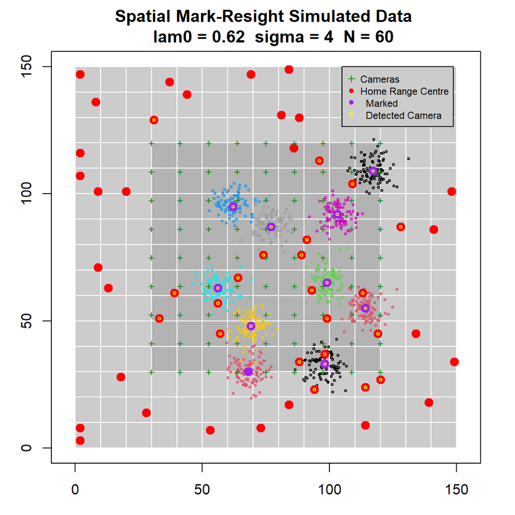

```r
par(mar = c(3,3,3,2))
popn <- sim.popn(D = 60/2.25, trW, buffer = 30, Ndist = 'fixed')
ch <- getWCH (trW,
              popn       = popn,
              detectfn   = 'HHN',
              detectpar  = list(lambda0 = 0.62, sigma = 4),
              noccasions = 5,
              ntelem     = 10,
              nocctelem  = 100,
              plotSim    = TRUE)
```

```r
# and print summary
summary(ch)
```

```
## Object class       capthist
## Detector type      count (5), telemetry
## Telemetry type     marking
## Detector number    81
## Average spacing    11.25 m
## x-range            30 120 m
## y-range            30 120 m
##
## Usage range by occasion
##     1 2 3 4 5 6
## min 0 0 0 0 0 0
## max 1 1 1 1 1 1
##
## Marking occasions
##  1 2 3 4 5 6
##  0 0 0 0 0 1
##
## Counts by occasion
##                    1  2  3  4  5    6 Total
## n                  1  3  4  3  5   10    26
## u                  1  2  3  2  1    1    10
## f                  1  4  3  2  0    0    10
## M(t+1)             1  3  6  8  9   10    10
## losses             0  0  0  0  0    0     0
## detections         1  4  5  5  7 1000  1022
## detectors visited  1  3  5  5  5    0    19
## detectors used    81 81 81 81 81    0   405
##
## Empty histories :  1
## 10 telemetered animals, 9 detected
## 100-100 locations per animal, mean =  100, sd = 0
##
## Sightings by occasion
##            1  2  3  4  5 Total
## ID         1  4  5  5  7    22
## Not ID     0  0  0  0  0     0
## Unmarked  11  8 10 11 10    50
## Uncertain  0  0  0  0  0     0
## Total     12 12 15 16 17    72
```

```r
# fit model using the previous settings
fitarg$capthist <- ch
fitarg$trace <- FALSE
fitarg$mask <- mskW25
fit <- do.call(secr.fit, fitarg)
predict(fit)
```

```
##         link estimate SE.estimate      lcl      ucl
## D        log 32.76832    7.192296 21.41992 50.12918
## lambda0  log  0.52372    0.114108  0.34339  0.79875
## sigma    log  4.06042    0.063808  3.93728  4.18742
```

### Run TEL simulations

```r
TELsims <- secrdesign::run.scenarios(
            nrepl       = nrepl,
            scenarios   = scen,
            CH.function = "getWCH",
            trapset     = list(trW),
            maskset     = list(mskW25, mskW50),
            pop.args    = poparg,
            det.args    = detarg,
            fit         = TRUE,
            fit.args    = fitarg,
            chatnsim    = -1,      # analytic c-hat (fitarg$details$chatmethod): variance only
            ncores      = 18,
            byscenario  = TRUE,
            seed        = 123,
            verbose     = FALSE)
saveRDS(TELsims, file = 'TELsims_secr.RDS')
```

```r
# the same simulated data as for secr (same seed and call structure; neither fit uses random numbers)
source('rtmb_marking.R')
TELsimsR <- secrdesign::run.scenarios(
    nrepl        = nrepl,
    scenarios    = scen,
    CH.function  = "getWCH",
    trapset      = list(trW),
    maskset      = list(mskW25, mskW50),
    pop.args     = poparg,
    det.args     = detarg,
    fit          = FALSE,
    extractfn    = rtmb_extract_masks,   # chooses the mask by scenario$maskindex
    distribution = "binomial",
    ncores       = 18,
    byscenario   = TRUE,
    seed         = 123,
    verbose      = FALSE)
saveRDS(TELsimsR, file = 'TELsims_rtmb.RDS')
```

TELsims completed with 1000 replicates in 3.3 hours (secr) and 1.6 hours (RTMB), elapsed.

## Results

### Timing

‘proctime’ is the time in seconds for a single replicate.  
‘chat’ is the overdispersion factor used to correct the variances from the independent-Poisson model of sightings (to allow for aggregation across cameras and occasions).

These are averages.

```r
getTime <- function (sims) {
    data.frame(
        proctime = apply(sapply(sims$output, function(x)
            sapply(x, attr, 'proctime')),2,mean, na.rm = TRUE),
        chat = apply(sapply(sims$output, function(x)
            sapply(x, attr, 'chat')),2,mean, na.rm = TRUE)
    )
}
getTime(TELsims)
```

```
##    proctime   chat
## 1    5.0374 1.5511
## 2    4.6455 1.6922
## 3    7.5584 2.7400
## 4    4.7629 2.5635
## 5    5.4133 3.0375
## 6    5.5690 6.3220
## 7    2.3038 1.4464
## 8    3.2392 1.5434
## 9    5.0524 1.9925
## 10   2.2194 2.3387
## 11   2.8191 2.6292
## 12   4.5959 3.8725
## 13   5.0314 1.4832
## 14   5.8219 1.5265
## 15   5.9708 1.6868
## 16   5.0027 2.4193
## 17   5.5192 2.5770
## 18   6.8110 3.0072
## 19   2.2976 1.4028
## 20   3.0075 1.4394
## 21   5.1061 1.5381
## 22   2.3109 2.2155
## 23   3.0456 2.3241
## 24   4.1099 2.6091
```

### Raw counts

```
##        D lambda0 sigma  n   ndet   nmov   dpa unmarked nonID nzero
## 1  26.67    0.62     4  5  10.32  2.712 1.280    54.69    NA 0.583
## 2  26.67    0.62     4 10  20.27  5.203 1.258    44.17    NA 1.226
## 3  26.67    0.62     4 20  39.69 10.174 1.248    21.11    NA 2.577
## 4  26.67    1.85     4  5  23.51 10.486 2.020   166.24    NA 0.049
## 5  26.67    1.85     4 10  46.51 20.912 2.011   128.79    NA 0.161
## 6  26.67    1.85     4 20  91.77 41.147 1.994    62.70    NA 0.392
## 7  26.67    0.18     8  5  11.38  6.115 1.927    66.24    NA 0.616
## 8  26.67    0.18     8 10  22.56 12.187 1.911    54.13    NA 1.334
## 9  26.67    0.18     8 20  43.89 23.387 1.861    31.86    NA 2.941
## 10 26.67    0.54     8  5  31.67 24.663 4.175   200.35    NA 0.124
## 11 26.67    0.54     8 10  62.41 48.376 4.116   162.26    NA 0.263
## 12 26.67    0.54     8 20 120.80 92.982 3.997    95.70    NA 0.669
## 13 53.33    0.62     4  5  10.35  2.669 1.285   122.53    NA 0.553
## 14 53.33    0.62     4 10  20.33  5.191 1.269   110.87    NA 1.152
## 15 53.33    0.62     4 20  40.90 10.601 1.279    86.02    NA 2.259
## 16 53.33    1.85     4  5  23.53 10.508 2.012   365.54    NA 0.065
## 17 53.33    1.85     4 10  46.73 20.881 2.007   330.38    NA 0.144
## 18 53.33    1.85     4 20  93.10 41.276 2.002   259.90    NA 0.261
## 19 53.33    0.18     8  5  11.45  6.182 1.938   144.14    NA 0.643
## 20 53.33    0.18     8 10  22.86 12.420 1.942   131.96    NA 1.287
## 21 53.33    0.18     8 20  45.22 24.398 1.911   108.58    NA 2.764
## 22 53.33    0.54     8  5  31.83 24.742 4.198   431.04    NA 0.098
## 23 53.33    0.54     8 10  63.19 49.156 4.178   396.70    NA 0.233
## 24 53.33    0.54     8 20 124.41 96.247 4.107   326.38    NA 0.509
```

Averages –

| n | number of telemetered (marked) animals |
| --- | --- |
| ndet | number of camera detections |
| ndet | number of movements between cameras |
| dpa | detectors per detected animal |
| unmarked | detections of unmarked animals (Tu) |
| nonid | detections of marked but unidentified animals (Tm) |
| nzero | number of all-zero detection histories (marked animals never photographed) |

### Estimates

```
## Density
##        D lambda0 sigma true.D nvalid   EST  seEST      RB   seRB    RSE   RMSE  rRMSE    COV
## 1  26.67    0.62     4  26.67   1000 28.57 0.3799  0.0713 0.0142 0.3202 12.158 0.4559 0.9570
## 2  26.67    0.62     4  26.67   1000 27.48 0.1928  0.0304 0.0072 0.2229  6.146 0.2305 0.9640
## 3  26.67    0.62     4  26.67    996 26.99 0.1392  0.0123 0.0052 0.1633  4.404 0.1652 0.9558
## 4  26.67    1.85     4  26.67   1000 27.62 0.1837  0.0356 0.0069 0.2120  5.884 0.2207 0.9630
## 5  26.67    1.85     4  26.67   1000 26.70 0.1446  0.0013 0.0054 0.1721  4.569 0.1714 0.9560
## 6  26.67    1.85     4  26.67   1000 26.84 0.1257  0.0064 0.0047 0.1481  3.977 0.1491 0.9510
## 7  26.67    0.18     8  26.67   1000 29.29 0.3608  0.0983 0.0135 0.3190 11.699 0.4387 0.9570
## 8  26.67    0.18     8  26.67   1000 27.47 0.1843  0.0301 0.0069 0.2170  5.879 0.2205 0.9620
## 9  26.67    0.18     8  26.67   1000 27.01 0.1462  0.0130 0.0055 0.1546  4.633 0.1738 0.9320
## 10 26.67    0.54     8  26.67   1000 27.32 0.1859  0.0245 0.0070 0.1999  5.912 0.2217 0.9470
## 11 26.67    0.54     8  26.67   1000 26.75 0.1347  0.0032 0.0051 0.1578  4.258 0.1597 0.9490
## 12 26.67    0.54     8  26.67   1000 26.70 0.1132  0.0011 0.0042 0.1327  3.579 0.1342 0.9420
## 13 53.33    0.62     4  53.33   1000 57.73 0.7072  0.0824 0.0133 0.3188 22.781 0.4272 0.9610
```

[output cut: 67 more lines]

### Compare estimated and empirical variance of density estimate

The estimated SE should match the SD of the simulated estimates.

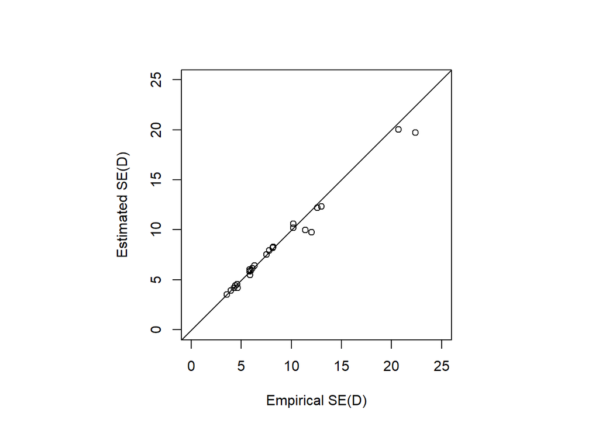

```r
par(pty = 's')
plot(apply(estimateArray(TELsims)[1,1,1,,],1,sd, na.rm = TRUE),
     apply(estimateArray(TELsims)[1,2,1,,],1,mean, na.rm = TRUE),
     xlab = 'Empirical SE(D)', ylab = 'Estimated SE(D)', xlim = c(0,25), ylim = c(0,25))
abline(0,1)
```

## Comparisons and Interpretation

Why might results differ from Appendix Table S2 of Whittington et al. (2025a) (ecs270246-sup-0001-appendixs1.pdf)?

```r
# read text file containing rows of Whittington et al. 2025a Appendix Table S2,
# excluding those for 2-phase analyses
S2 <- read.table ('AppTableS2.txt', header = TRUE)
print(S2, row.names = FALSE)
```

```
##  Scenario     Model   N sigma lam0 Detection nMarked Nmean Bias RMSE  CIC CVmean Time
##         1 One-stage  60     4 0.62       Low       5  66.1 10.1 13.4 95.0   20.4  3.1
##         2 One-stage  60     4 0.62       Low      10  62.3  3.8 11.2 97.0   20.1  3.5
##         3 One-stage  60     4 0.62       Low      20  62.6  4.3  9.8 97.5   19.0  4.0
##         4 One-stage  60     4 1.85      High       5  61.2  2.0  9.8 96.5   16.9  3.1
##         5 One-stage  60     4 1.85      High      10  62.0  3.3  9.3 95.8   15.9  3.6
##         6 One-stage  60     4 1.85      High      20  62.4  4.0  8.5 97.6   15.3  4.2
##         7 One-stage  60     8 0.18       Low       5  63.6  6.0 12.3 99.0   23.4  3.3
##         8 One-stage  60     8 0.18       Low      10  64.4  7.4 11.5 99.5   21.2  3.4
##         9 One-stage  60     8 0.18       Low      20  62.8  4.7  9.4 98.5   19.5  4.2
##        10 One-stage  60     8 0.54      High       5  62.4  4.0 10.7 95.9   17.8  3.3
##        11 One-stage  60     8 0.54      High      10  62.2  3.7  9.3 95.2   16.0  3.6
##        12 One-stage  60     8 0.54      High      20  60.9  1.6  7.3 97.5   14.7  4.4
##        13 One-stage 120     4 0.62       Low       5 128.4  7.0 24.5 95.2   19.2  6.2
##        14 One-stage 120     4 0.62       Low      10 126.3  5.3 19.9 98.3   17.7  5.6
##        15 One-stage 120     4 0.62       Low      20 125.3  4.4 18.8 97.0   16.2  6.7
##        16 One-stage 120     4 1.85      High       5 125.6  4.6 19.1 95.3   14.7  5.5
##        17 One-stage 120     4 1.85      High      10 123.5  2.9 16.7 95.0   13.4  6.0
##        18 One-stage 120     4 1.85      High      20 121.2  1.0 12.8 97.2   12.3  6.5
##        19 One-stage 120     8 0.18       Low       5 126.5  5.4 24.0 98.2   22.5  5.3
##        20 One-stage 120     8 0.18       Low      10 130.1  8.4 23.6 95.4   19.6  6.2
##        21 One-stage 120     8 0.18       Low      20 126.9  5.7 19.7 95.9   16.9  6.5
##        22 One-stage 120     8 0.54      High       5 124.4  3.7 19.6 96.8   16.5  6.7
##        23 One-stage 120     8 0.54      High      10 125.2  4.4 16.7 96.5   14.0  6.8
##        24 One-stage 120     8 0.54      High      20 122.1  1.7 13.3 96.1   11.9  7.2
```

```r
# simulation results (TELsims, TELsimsR) were read above

# define matrix with min,max density for each scenario
permitted <- outer(TELsims$scenarios$D, c(0, 1/0.6))

# summarise filtered results
simsum <- estimateSummary(TELsims, 'D', validrange = permitted)
simsum
```

```
##    scenario true.D nvalid   EST  seEST         RB     seRB    RSE   RMSE  rRMSE    COV
## 1         1  26.67    930 26.19 0.2262 -0.0177888 0.008482 0.3090  6.910 0.2591 0.9753
## 2         2  26.67    990 27.27 0.1824  0.0224908 0.006841 0.2226  5.768 0.2163 0.9737
## 3         3  26.67    996 26.99 0.1392  0.0123015 0.005222 0.1633  4.404 0.1652 0.9558
## 4         4  26.67    991 27.41 0.1713  0.0278943 0.006425 0.2118  5.442 0.2041 0.9717
## 5         5  26.67    999 26.68 0.1434  0.0005294 0.005378 0.1721  4.530 0.1699 0.9570
## 6         6  26.67   1000 26.84 0.1257  0.0063663 0.004714 0.1481  3.977 0.1491 0.9510
## 7         7  26.67    913 26.68 0.2246  0.0003168 0.008422 0.3061  6.783 0.2544 0.9726
## 8         8  26.67    989 27.25 0.1735  0.0218100 0.006507 0.2165  5.485 0.2057 0.9727
## 9         9  26.67    997 26.95 0.1425  0.0107189 0.005343 0.1545  4.506 0.1690 0.9348
## 10       10  26.67    989 27.08 0.1730  0.0156009 0.006489 0.1996  5.455 0.2046 0.9575
## 11       11  26.67    999 26.73 0.1337  0.0024908 0.005012 0.1578  4.223 0.1584 0.9499
## 12       12  26.67   1000 26.70 0.1132  0.0011027 0.004246 0.1327  3.579 0.1342 0.9420
## 13       13  53.33    935 53.60 0.4414  0.0050449 0.008276 0.3076 13.492 0.2530 0.9690
## 14       14  53.33    976 54.52 0.3509  0.0221680 0.006580 0.2169 11.021 0.2066 0.9744
## 15       15  53.33   1000 53.31 0.2582 -0.0004154 0.004842 0.1550  8.162 0.1530 0.9510
## 16       16  53.33    997 54.31 0.3156  0.0183667 0.005917 0.1937 10.007 0.1876 0.9679
## 17       17  53.33   1000 53.61 0.2459  0.0051288 0.004610 0.1484  7.775 0.1458 0.9540
## 18       18  53.33   1000 53.52 0.1999  0.0035788 0.003748 0.1203  6.320 0.1185 0.9530
## 19       19  53.33    919 54.36 0.4600  0.0193008 0.008625 0.3077 13.976 0.2620 0.9684
## 20       20  53.33    979 54.61 0.3501  0.0239045 0.006565 0.2137 11.023 0.2067 0.9714
## 21       21  53.33   1000 54.07 0.2573  0.0138838 0.004825 0.1506  8.167 0.1531 0.9500
## 22       22  53.33    994 53.81 0.2984  0.0089129 0.005594 0.1867  9.414 0.1765 0.9668
## 23       23  53.33   1000 53.75 0.2378  0.0078325 0.004458 0.1397  7.527 0.1411 0.9590
## 24       24  53.33   1000 53.45 0.1887  0.0021894 0.003537 0.1107  5.964 0.1118 0.9530
```

```r
# How many knocked out by validrange?
estimateSummary(TELsims, 'D')$nvalid - simsum$nvalid
```

```
##  [1] 70 10  0  9  1  0 87 11  3 11  1  0 65 24  0  3  0  0 81 21  0  6  0  0
```

Comparing current simulations (‘current’) with Whittington et al. (2025a) (‘Table S2’).

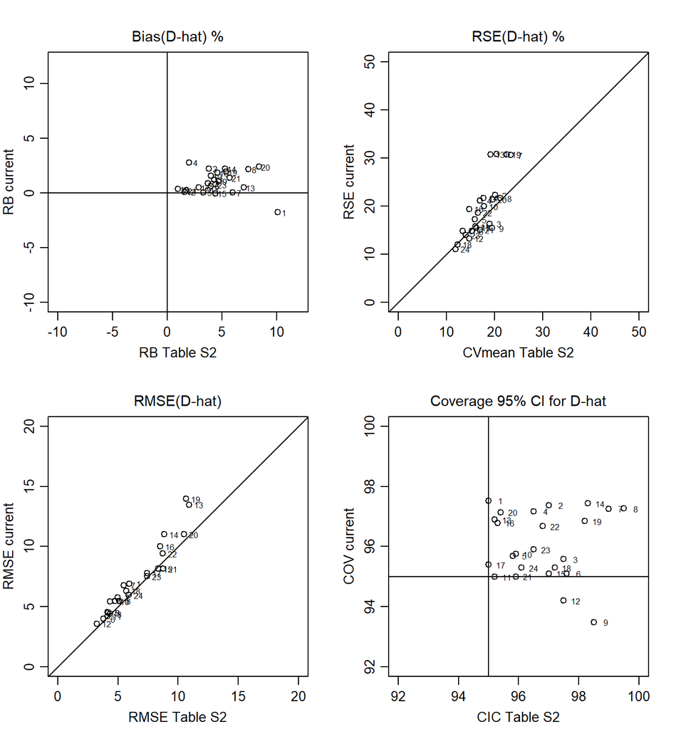

```r
par(pty = 's', mfrow = c(2,2), mar = c(3,3,3,2), mgp = c(2,0.7,0))

plot(S2$Bias, simsum$RB*100, xlab = 'RB Table S2', ylab = 'RB current',
     xlim=c(-10,12), ylim=c(-10,12))
text(S2$Bias+0.6, simsum$RB*100, 1:24, cex = 0.6)
abline(h=0, v=0)
mtext(side=3, line=0.5, 'Bias(D-hat) %', cex=0.9)

plot(S2$CVmean, simsum$RSE*100, xlab = 'CVmean Table S2', ylab = 'RSE current',
     xlim=c(0,50), ylim=c(0,50))
text(S2$CVmean+2, simsum$RSE*100, 1:24, cex=0.6)
abline(0,1)
mtext(side=3, line=0.5, 'RSE(D-hat) %', cex=0.9)

# Whittington et al. RMSE is for N-hat, so divide by 2.25 ha to convert to density
plot(S2$RMSE/2.25, simsum$RMSE, xlab = 'RMSE Table S2', ylab = 'RMSE current',
     xlim=c(0,20), ylim=c(0,20))
text(S2$RMSE/2.25+0.8, simsum$RMSE, 1:24, cex=0.6)
abline(0,1)
mtext(side=3, line=0.5, 'RMSE(D-hat)', cex=0.9)

plot(S2$CIC, simsum$COV*100, xlab = 'CIC Table S2', ylab = 'COV current',
     xlim=c(92,100), ylim=c(92,100))
text(S2$CIC+0.4, simsum$COV*100, 1:24, cex=0.6)
mtext(side=3, line=0.5, 'Coverage 95% CI for D-hat', cex=0.9)
abline(h=95,v=95)
```

### Comparison with an independent RTMB implementation

The same simulated datasets were fitted by maximum likelihood in RTMB (Appendix 1). The RTMB likelihood treats the total of sightings of unmarked animals as negative binomial, so small differences in the estimates of D are expected. The summaries below use the same filter on D as above.

```r
simsumR <- estimateSummary(TELsimsR, 'D', validrange = permitted)
cmp <- data.frame(scenarios[,1:3],
    RB.secr = round(simsum$RB*100,1), RB.RTMB = round(simsumR$RB*100,1),
    RSE.secr = round(simsum$RSE*100,1), RSE.RTMB = round(simsumR$RSE*100,1),
    COV.secr = round(simsum$COV*100,1), COV.RTMB = round(simsumR$COV*100,1))
cmp
```

```
##        D lambda0 sigma RB.secr RB.RTMB RSE.secr RSE.RTMB COV.secr COV.RTMB
## 1  26.67    0.62     4    -1.8    -0.8     30.9     29.8     97.5     97.5
## 2  26.67    0.62     4     2.2     3.5     22.3     21.6     97.4     97.2
## 3  26.67    0.62     4     1.2     4.0     16.3     14.9     95.6     93.6
## 4  26.67    1.85     4     2.8     3.9     21.2     20.7     97.2     97.0
## 5  26.67    1.85     4     0.1     1.5     17.2     16.8     95.7     95.1
## 6  26.67    1.85     4     0.6     3.6     14.8     13.5     95.1     92.0
## 7  26.67    0.18     8     0.0     0.6     30.6     29.5     97.3     97.3
## 8  26.67    0.18     8     2.2     3.1     21.7     21.2     97.3     97.3
## 9  26.67    0.18     8     1.1     2.8     15.4     14.8     93.5     92.8
## 10 26.67    0.54     8     1.6     2.4     20.0     19.6     95.8     95.6
## 11 26.67    0.54     8     0.2     1.3     15.8     15.5     95.0     95.3
## 12 26.67    0.54     8     0.1     1.8     13.3     12.7     94.2     93.5
## 13 53.33    0.62     4     0.5     0.9     30.8     29.6     96.9     96.9
## 14 53.33    0.62     4     2.2     2.8     21.7     21.3     97.4     97.3
## 15 53.33    0.62     4     0.0     0.7     15.5     15.3     95.1     94.9
## 16 53.33    1.85     4     1.8     2.4     19.4     19.0     96.8     96.6
## 17 53.33    1.85     4     0.5     1.1     14.8     14.7     95.4     95.3
## 18 53.33    1.85     4     0.4     1.1     12.0     11.9     95.3     95.7
## 19 53.33    0.18     8     1.9     2.2     30.8     29.4     96.8     96.5
## 20 53.33    0.18     8     2.4     2.7     21.4     20.9     97.1     96.7
## 21 53.33    0.18     8     1.4     1.9     15.1     14.9     95.0     94.8
## 22 53.33    0.54     8     0.9     1.3     18.7     18.3     96.7     96.7
## 23 53.33    0.54     8     0.8     1.1     14.0     13.8     95.9     95.9
## 24 53.33    0.54     8     0.2     0.7     11.1     11.0     95.3     95.0
```

```r
# paired comparison: both methods were fitted to the same data
ratio <- sapply(seq_along(TELsims$output), function(i) mean(
    mapply(function(a, b) a['D','estimate'] / b['D','estimate'],
           TELsims$output[[i]], TELsimsR$output[[i]]), na.rm = TRUE))
cat('Mean over scenarios of mean ratio of D estimates, secr / RTMB:', round(mean(ratio), 4), '\n')
```

```
## Mean over scenarios of mean ratio of D estimates, secr / RTMB: 0.9897
```

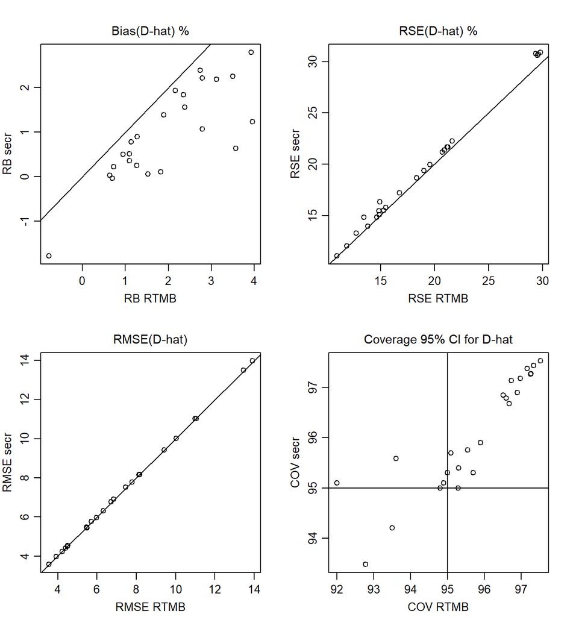

```r
par(pty = 's', mfrow = c(2,2), mar = c(3,3,3,2), mgp = c(2,0.7,0))
plot(simsumR$RB*100, simsum$RB*100, xlab = 'RB RTMB', ylab = 'RB secr'); abline(0,1)
mtext(side=3, line=0.5, 'Bias(D-hat) %', cex=0.9)
plot(simsumR$RSE*100, simsum$RSE*100, xlab = 'RSE RTMB', ylab = 'RSE secr'); abline(0,1)
mtext(side=3, line=0.5, 'RSE(D-hat) %', cex=0.9)
plot(simsumR$RMSE, simsum$RMSE, xlab = 'RMSE RTMB', ylab = 'RMSE secr'); abline(0,1)
mtext(side=3, line=0.5, 'RMSE(D-hat)', cex=0.9)
plot(simsumR$COV*100, simsum$COV*100, xlab = 'COV RTMB', ylab = 'COV secr'); abline(h=95, v=95)
mtext(side=3, line=0.5, 'Coverage 95% CI for D-hat', cex=0.9)
```

### Compare timing

Average time per replicate in seconds. The time for **secr** includes both fitting steps (the model fit and the analytic overdispersion adjustment). Times depend on the machine and the number of replicates running at once.

```r
se <- function(x) sd(x, na.rm=TRUE) / sqrt(sum(!is.na(x)))
secrtime <- unlist(lapply(TELsims$output, function(x) sapply(x, attr, 'proctime')))
rtmbtime <- unlist(lapply(TELsimsR$output, function(x) sapply(x, attr, 'proctime')))
cat('secr\n')
c(mean = mean(secrtime, na.rm = TRUE), SE = se(secrtime))
cat('\nRTMB\n')
c(mean = mean(rtmbtime, na.rm = TRUE), SE = se(rtmbtime))
cat('\nTable S2\n')
c(mean = mean(S2$Time*60), SE = se(S2$Time*60))
```

```
## secr
##    mean      SE
## 4.46879 0.01075
##
## RTMB
##    mean      SE
## 2.57968 0.00732
##
## Table S2
##   mean     SE
## 297.25  17.56
```

# References

Chandler, R. B., Crawford, D. A., Garrison, E. P., Miller, K. V., and Cherry, M. J. (2021) Modeling abundance, distribution, movement and space use with camera and telemetry data. Ecology 103: e3583. https://doi.org/10.1002/ecy.3583

Efford, M. G. and Hunter, C. M. (2018) Spatial capture–mark–resight estimation of animal population density. Biometrics 74: 411–420. https://doi.org/10.1111/biom.12766

Efford, M. G. and Mowat, G. (2014) Compensatory heterogeneity in spatially explicit capture–recapture data. Ecology 95: 1341–1348. https://www.otago.ac.nz/density/pdfs/Efford%20and%20Mowat%202014%20Ecology.pdf

Efford, M. G. (2025) The SECR book. A handbook of spatially explicit capture–recapture methods. Version 1.0.0. Zenodo https://doi.org/10.5281/zenodo.15109938.

Kristensen K, Nielsen A, Berg CW, Skaug H, Bell BM (2016) TMB: Automatic differentiation and Laplace approximation. Journal of Statistical Software 70: 1–21. https://doi.org/10.18637/jss.v070.i05

Kristensen, K. (2026) RTMB: ‘R’ Bindings for ‘TMB’. R package version 2.0, https://CRAN.R-project.org/package=RTMB.

Margenau, L. L. S., Cherry, M. J., Miller, K. V., Garrison, E. P., and Chandler, R. B. (2022) Monitoring partially marked populations using camera and telemetry data. Ecological Applications 32: e2553. https://doi.org/10.1002/eap.2553

Meyer, C. J., Whittington, J., Tourani, M., and Hebblewhite, M. (2026) A novel generalized spatial mark‐resight model that accounts for group associations. Methods in Ecology and Evolution 17: 1275–1289. https://doi.org/10.1111/2041-210x.70271

Murphy, S. M., Wilckens, D. T., Augustine, B. C., Peyton, M. A., and Harper, G. C. (2019) Improving estimation of puma (*Puma concolor*) population density: clustered camera-trapping, telemetry data, and generalized spatial mark-resight models. Scientific Reports 9: 4590 https://doi.org/10.1038/s41598-019-40926-7

Royle, J. A., Chandler, R. B., Sollmann, R. and Gardner, B. (2014) *Spatial capture–recapture.* Academic Press.

Whittington, J., Hebblewhite, M., and Chandler, R. (2018) Generalized spatial mark-resight models with an application to grizzly bears. Journal of Applied Ecology 55: 157–168. https://doi.org/10.1111/1365-2664.12954

Whittington, J., Hebblewhite, M., Meyer, C., Johnston, B., Forshner, A., Macbeth, B. J., Einfeldt, A. L., and Cherry, S. G. (2025a) One‐stage spatial mark–resight analysis reveals an increasing grizzly bear population with declining density near roads. Ecosphere 16: e70246. https://doi.org/10.1002/ecs2.70246

Whittington, J., Hebblewhite, M., Meyer, C., Johnston, B., Forshner, A., Macbeth, B., Einfeldt, A., and Cherry, S. (2025b). Data from: One-stage spatial mark-resight analysis reveals an increasing grizzly bear population with declining density near roads [Computer software]. Zenodo. https://doi.org/10.5281/zenodo.10198936

# Appendix 1. RTMB implementation

This is the code in file ‘rtmb_marking.R’ used for the comparison with RTMB. It is an independent implementation of the one-stage likelihood for telemetry type ‘marking’ and is not run when this document is rendered. `rtmb_extract_masks` is the `extractfn` used with `run.scenarios(fit = FALSE)`.

```r
###############################################################################
## rtmb_marking.R
## One-stage maximum likelihood for telemetry-marking data with RTMB, as an independent
## implementation of the model fitted by secr::secr.fit for telemetry type 'marking'.
## Use as the 'extractfn' of secrdesign::run.scenarios(fit = FALSE, ...)
## (see function rtmb_extract at the end of this file).
##
## Model (count detectors, homogeneous density, hazard half-normal, uniform prior for
## the activity centres of the collared animals):
##   * collared animal i: identified cue counts Poisson(q U_k lambda_k(s_i)); n_i telemetry
##     fixes bivariate normal about s_i with the same sigma as the detection function; the
##     activity centre s_i is integrated out by Gauss-Hermite quadrature about the mean fix
##     (or summed over the mask if the animal has no fixes);
##   * unmarked cues: total C_u negative binomial with mean mu = D J1 - sum_i E_i[L(s_i)],
##     where J1 = integral of the cue rate L(x) over the mask and E_i is the posterior mean
##     given animal i's own data, and variance c-hat * mu (compound-Poisson; Poisson or
##     fixed number of animals; the posterior variance of the collared animals' cues is
##     included); c-hat is estimated in a first pass and then held fixed;
##   * unidentified marked cues Tm (optional): Poisson((1 - q) U_k sum_i E_i[lambda_k]).
## Differences from secr: the unmarked total is negative binomial rather than Poisson
## with a variance scale factor (point estimates of D differ by 0.4-2%), and there is no
## density model.
##
## Requires packages RTMB and secr (exported functions only). Units: mask area in
## hectares gives density per hectare.
###############################################################################

## Gauss-Hermite nodes and weights for a standard normal (probabilists'), n nodes
gh_std_normal <- function (n) {
    J <- matrix(0, n, n)
    if (n > 1) for (i in 1:(n - 1)) J[i, i + 1] <- J[i + 1, i] <- sqrt(i)
    e <- eigen(J, symmetric = TRUE)
    list(z = e$values, w = e$vectors[1, ]^2)
}

## Fit to a capthist of telemetry type 'marking'.
## distribution: "binomial" (fixed N) or "poisson". Returns a list, or NULL if the fit failed.
fit_rtmb_marking <- function (capthist, mask, distribution = c("binomial", "poisson"),
                              ngh = 7, trace = FALSE) {
    ## RTMB must be attached (not just loaded): its automatic-differentiation versions of
    ## functions such as plogis and lgamma are used by the likelihood below
    suppressPackageStartupMessages(require(RTMB))
    distribution <- match.arg(distribution)
    ptm <- proc.time()

    ## 1. Data --------------------------------------------------------------
    traps <- secr::traps(capthist)
    ## number of sighting detectors: all rows of 'traps' except the notional telemetry detector
    ## (detector() has one element per occasion, not per detector)
    K0    <- nrow(traps) - any(secr::detector(traps) == "telemetry")
    S     <- sum(secr::markocc(traps) == 0)                   # sighting occasions
    CH0   <- apply(capthist[, 1:S, 1:K0, drop = FALSE], c(1, 3), sum)   # n x K0 identified cues
    traps_xy <- as.matrix(traps[1:K0, ])
    u     <- secr::usage(traps)
    usage <- if (is.null(u)) matrix(1, K0, S) else as.matrix(u)[1:K0, 1:S, drop = FALSE]
    U0    <- rowSums(usage)
    keep  <- U0 > 0                      # unused detectors carry no information
    K     <- sum(keep)
    CH    <- CH0[, keep, drop = FALSE]
    U     <- U0[keep]
    trap_xy <- traps_xy[keep, , drop = FALSE]
    n     <- nrow(CH)

    mask_xy <- as.matrix(mask)
    a       <- attr(mask, "area")
    M       <- nrow(mask_xy)
    A_mask  <- M * a

    Tu  <- attr(capthist, "Tu")
    if (is.null(Tu)) stop("capthist has no Tu attribute")
    C_u <- sum(Tu)
    Tm  <- attr(capthist, "Tm")
    Tm_k <- if (is.null(Tm)) rep(0, K) else rowSums(as.matrix(Tm)[1:K0, 1:S, drop = FALSE])[keep]
    has_Tm <- sum(Tm_k) > 0

    telem <- secr::telemetryxy(capthist)
    has_tel <- if (length(telem) == n) vapply(seq_len(n), function(i)
        !is.null(telem[[i]]) && nrow(telem[[i]]) > 0, logical(1)) else rep(FALSE, n)
    tel_i <- which(has_tel); non_i <- which(!has_tel)
    telinfo <- lapply(tel_i, function(i) {
        tx <- as.matrix(telem[[i]]); tb <- colMeans(tx)
        list(tb = tb, nl = nrow(tx), ssd = sum(sweep(tx, 2, tb)^2)) })

    gh <- gh_std_normal(ngh)
    zz <- as.matrix(expand.grid(z1 = gh$z, z2 = gh$z))
    logw_gh <- log(as.vector(outer(gh$w, gh$w)))
    G  <- nrow(zz)

    d2m <- outer(mask_xy[, 1], trap_xy[, 1], "-")^2 + outer(mask_xy[, 2], trap_xy[, 2], "-")^2  # M x K
    Cm  <- matrix(rep(trap_xy[, 1], each = G), G, K)
    Cy  <- matrix(rep(trap_xy[, 2], each = G), G, K)
    lgY <- rowSums(lgamma(CH + 1))
    dat <- list(CH = CH, U = U, K = K, S = S, n = n, M = M, a = a, A_mask = A_mask,
                d2m = d2m, Cm = Cm, Cy = Cy, G = G, z1 = zz[, 1], z2 = zz[, 2], logw = logw_gh,
                tel_i = tel_i, non_i = non_i, telinfo = telinfo,
                YlogU = as.vector(CH %*% log(U)), sumY = rowSums(CH), lgY = lgY,
                Tm_k = Tm_k, Tm_pos = which(Tm_k > 0), lgTm = sum(lgamma(Tm_k + 1)), has_Tm = has_Tm,
                C_u = C_u, distribution = distribution, chat_on_tape = TRUE, chat = NA_real_)

    ## 2. Starting values ---------------------------------------------------
    s_init <- t(vapply(seq_len(n), function(i) {
        if (has_tel[i]) telinfo[[match(i, tel_i)]]$tb
        else if (any(CH[i, ] > 0)) colMeans(trap_xy[CH[i, ] > 0, , drop = FALSE])
        else colMeans(trap_xy)
    }, numeric(2)))
    sig0 <- if (any(has_tel)) {
        sqrt(sum(vapply(telinfo, function(x) x$ssd, 0)) / (2 * sum(vapply(telinfo, function(x) x$nl, 0))))
    } else secr::RPSV(capthist, CC = TRUE)
    Lam_at <- function(xy, lam0, sig)
        rowSums(sapply(1:K, function(k)
            U[k] * lam0 * exp(-((xy[, 1] - trap_xy[k, 1])^2 + (xy[, 2] - trap_xy[k, 2])^2) / (2 * sig^2))))
    lam00 <- (sum(CH) + sum(Tm_k)) / max(sum(Lam_at(s_init, 1, sig0)), 1e-12)
    lam00 <- min(max(lam00, 1e-6), 10)
    I10   <- sum(Lam_at(mask_xy, lam00, sig0)) * a
    Du0   <- max(C_u, 1) / I10
    q0    <- if (has_Tm) min(max(sum(CH) / (sum(CH) + sum(Tm_k)), 0.1), 0.9) else 1
```